```python
%reset -f
```

# DeepHit pour un événement unique concernant les délais de paiement

Dans ce notebook, nous allons expliquer comment nous avons ajusté un modèle DeepHit pour un seul type d'événement, en nous concentrant sur les délais de paiement.

Pour mener à bien cette modélisation, certains packages supplémentaires, qui ne sont pas installés par défaut, sont nécessaires.

```python
## Uncomment to install `sklearn-pandas`
! pip install sklearn-pandas
! pip install torchtuples
! pip install pycox
```

De même, pour les packages déjà installés, il est nécessaire de les importer afin de pouvoir les utiliser dans notre modèle DeepHit.

```python
import numpy as np
import pandas as pd
import matplotlib.pyplot as plt

import importlib.util
import sys

# For preprocessing
from sklearn.preprocessing import StandardScaler
from sklearn_pandas import DataFrameMapper

import torch # For building the networks
import torchtuples as tt # Some useful functions

from pycox.datasets import metabric
from pycox.models import DeepHitSingle
from pycox.evaluation import EvalSurv
```

```python
np.random.seed(1234)
_ = torch.manual_seed(123)
```

## Les données DP

Les données ont été mises temporairement sur le drive pour pouvoir les importer plus facilement.

```python
from google.colab import drive
drive.mount('/content/drive')
```

Ici, nous ne sommes pas en présence de données censurées.

```python
# Chemin vers le fichier dans Google Drive
file_path = '/content/drive/My Drive/ModelePy.csv'

# Lire le fichier CSV dans un DataFrame pandas
ModeleCox = pd.read_csv(file_path)

ModeleCox = ModeleCox[(ModeleCox['CB'] != '#') & (ModeleCox['SB'] != '#')].iloc[:, 1:]

print(ModeleCox.head())
```

```
   CG  AB  SB  RB  CB  TC  TP  PS  PP  DP     RO
0   1  18   1   1   3   1   2   2   5  42   9.68
1   1  95   1  10   1   2   2   6   7  39  67.08
2   1  93   2   3   1   2   2  10  11  50   3.78
3   1  69   2   5   2   1   2  32  32  35  52.92
4   1  81   1  10   2   2   2  27  27  35  46.43
```

```python
df_train = ModeleCox
df_test = df_train.sample(frac=0.2)
df_train = df_train.drop(df_test.index)
df_val = df_train.sample(frac=0.2)
df_train = df_train.drop(df_val.index)
```

```python
df_train.head()
```

|  | CG | AB | SB | RB | CB | TC | TP | PS | PP | DP | RO |
| --- | --- | --- | --- | --- | --- | --- | --- | --- | --- | --- | --- |
| 0 | 1 | 18 | 1 | 1 | 3 | 1 | 2 | 2 | 5 | 42 | 9.68 |
| 1 | 1 | 95 | 1 | 10 | 1 | 2 | 2 | 6 | 7 | 39 | 67.08 |
| 2 | 1 | 93 | 2 | 3 | 1 | 2 | 2 | 10 | 11 | 50 | 3.78 |
| 3 | 1 | 69 | 2 | 5 | 2 | 1 | 2 | 32 | 32 | 35 | 52.92 |
| 4 | 1 | 81 | 1 | 10 | 2 | 2 | 2 | 27 | 27 | 35 | 46.43 |

## Transformations des caractéristiques

Nous recommandons d'utiliser `sklearn_pandas.DataFrameMapper` pour créer des mappers de fonctionnalités de manière efficace.

```python
cols_standardize =  df_train.columns.tolist()

standardize = [([col], StandardScaler()) for col in cols_standardize]

x_mapper = DataFrameMapper(standardize)
```

```python
x_train = x_mapper.fit_transform(df_train).astype('float32')
x_val = x_mapper.transform(df_val).astype('float32')
x_test = x_mapper.transform(df_test).astype('float32')
```

## Transformations des étiquettes

Les méthodes de survie nécessitent des transformations spécifiques des étiquettes pour chaque individu. Nous avons donc inclus une transformation des étiquettes proposée pour chaque méthode. Dans ce cas, `label_transform` est simplement un raccourci pour la classe `pycox.preprocessing.label_transforms.LabTransDiscreteTime`.

DeepHit est une méthode à temps discret, ce qui signifie qu'elle nécessite une discrétisation des temps d'événements pour être appliquée aux données en temps continu. Nous définissons `num_durations` pour la taille de cette grille de discrétisation (équidistante), ce qui signifie que notre réseau aura `num_durations` nœuds de sortie.

```python
num_durations = 10
labtrans = DeepHitSingle.label_transform(num_durations)
get_target = lambda df: (df['DP'].values, np.ones(len(df)))
y_train = labtrans.fit_transform(*get_target(df_train))
y_val = labtrans.transform(*get_target(df_val))

train = (x_train, y_train)
val = (x_val, y_val)

# We don't need to transform the test labels
durations_test, events_test = get_target(df_test)
```

```python
type(labtrans)
```

```
pycox.preprocessing.label_transforms.LabTransDiscreteTime
def __init__(cuts, scheme='equidistant', min_=0.0, dtype=None)
```

[output not shown]

## Réseau de neurones

Nous construisons un réseau de neurones avec PyTorch. Pour des structures de réseau simples, nous pouvons utiliser le MLPVanilla fourni par torchtuples. Pour des architectures de réseau plus avancées, consultez par exemple les tutoriels de PyTorch.

```python
in_features = x_train.shape[1]
num_nodes = [32, 32]
out_features = labtrans.out_features
batch_norm = True
dropout = 0.1

net = tt.practical.MLPVanilla(in_features, num_nodes, out_features, batch_norm, dropout)
```

Si vous préférez construire ce réseau avec PyTorch, vous pouvez décommenter le code suivant. Il est essentiellement équivalent au MLPVanilla, mais sans l'initialisation des poids `torch.nn.init.kaiming_normal_`.

```python
# net = torch.nn.Sequential(
#     torch.nn.Linear(in_features, 32),
#     torch.nn.ReLU(),
#     torch.nn.BatchNorm1d(32),
#     torch.nn.Dropout(0.1),

#     torch.nn.Linear(32, 32),
#     torch.nn.ReLU(),
#     torch.nn.BatchNorm1d(32),
#     torch.nn.Dropout(0.1),

#     torch.nn.Linear(32, out_features)
# )
```

## Entraînement du modèle

Pour entraîner le modèle, nous devons définir un optimiseur. Vous pouvez choisir n'importe quel optimiseur de `torch.optim`, mais ici nous utilisons plutôt un de `tt.optim` car il offre des fonctionnalités supplémentaires. Nous utilisons l'optimiseur Adam, mais au lieu de choisir un taux d'apprentissage, nous utiliserons le schéma proposé par Smith 2017 pour trouver un taux d'apprentissage approprié avec `model.lr_finder`. Consultez ce post pour une explication.

Nous définissons également `duration_index`, qui relie les nœuds de sortie du réseau aux temps de discrétisation. Cela est uniquement utile pour la prédiction et n'affecte pas la procédure d'entraînement.

DeepHit a une perte qui est une combinaison d'une log-vraisemblance négative et d'une perte de classement. `alpha` est un paramètre qui contrôle la combinaison linéaire entre les deux, et `sigma` est un paramètre utilisé par la perte de classement. `alpha = 1` donne une perte contenant uniquement la log-vraisemblance négative, et `alpha = 0` donne une perte de classement pure. Notez que cela diffère du papier original.

```python
model = DeepHitSingle(net, tt.optim.Adam, alpha=0.2, sigma=0.1, duration_index=labtrans.cuts)
```

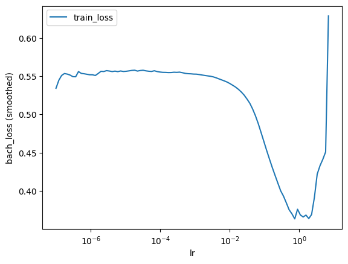

```python
batch_size = 256
lr_finder = model.lr_finder(x_train, y_train, batch_size, tolerance=3)
_ = lr_finder.plot()
```

```python
lr_values = lr_finder.lrs  # Taux d'apprentissage

# Convertir les données en DataFrame pandas
df_lr_finder = pd.DataFrame({
    'Learning Rate': lr_values,
})

excel_path = '/content/drive/My Drive/lr_finder_dataDeepHit.xlsx'
df_lr_finder.to_excel(excel_path, index=False)
```

```python
lr_finder.get_best_lr()
```

```
0.07390722033525823
```

Souvent, ce taux d'apprentissage est un peu élevé, donc nous le réglons manuellement à 0,01 à la place.

```python
model.optimizer.set_lr(0.01)
```

Nous incluons le callback EarlyStopping pour arrêter l'entraînement lorsque la perte de validation cesse de s'améliorer. Après l'entraînement, ce callback chargera également le meilleur modèle en termes de perte de validation.

```python
epochs = 100
callbacks = [tt.callbacks.EarlyStopping()]
log = model.fit(x_train, y_train, batch_size, epochs, callbacks, val_data=val)
```

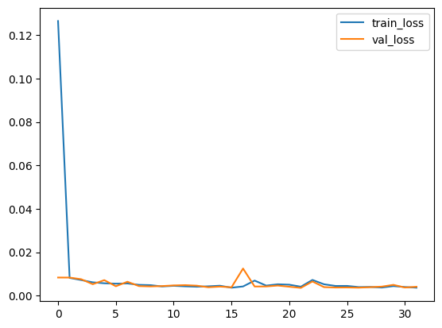

```python
_ = log.plot()
```

## Prediction

Pour l'évaluation, nous devons d'abord obtenir les estimations de survie pour l'ensemble de test. Cela peut se faire avec `model.predict_surv`, qui retourne un tableau d'estimations de survie, ou avec `model.predict_surv_df`, qui retourne les estimations de survie sous forme de DataFrame.

```python
surv = model.predict_surv_df(x_test)
```

Nous pouvons tracer les estimations de survie pour les 5 premiers individus. Notez que l'échelle temporelle est correcte car nous avons défini `model.duration_index` comme étant les points de la grille. Cependant, nous avons seulement défini les estimations de survie aux 10 instants de notre grille de discrétisation, donc les estimations de survie sont une fonction en escalier.

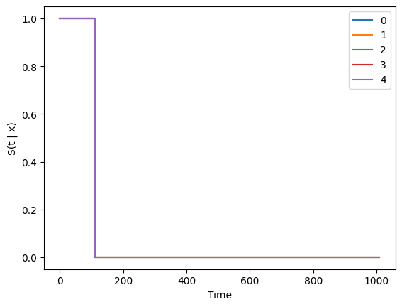

```python
surv.iloc[:, :5].plot(drawstyle='steps-post')
plt.ylabel('S(t | x)')
_ = plt.xlabel('Time')
```

Il est donc souvent avantageux d'interpoler les estimations de survie. L'interpolation linéaire (interpolation à densité constante) peut être réalisée avec la méthode `interpolate`. Nous devons également choisir combien de points nous voulons utiliser pour remplacer chaque point de grille. Ici, nous utiliserons 10 points.

```python
surv = model.interpolate(10).predict_surv_df(x_test)
```

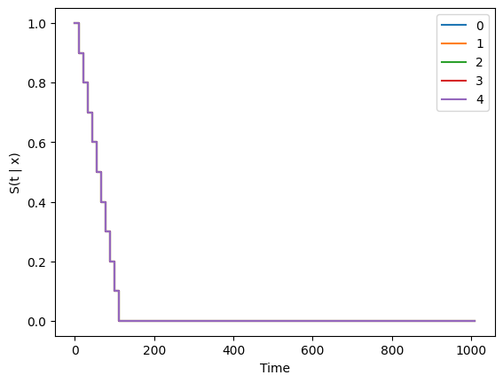

```python
surv.iloc[:, :5].plot(drawstyle='steps-post')
plt.ylabel('S(t | x)')
_ = plt.xlabel('Time')
```

Les courbes de survie sont presque identiques pour les 5 individus.

## Evaluation

La classe `EvalSurv` contient des critères d'évaluation utiles pour la prédiction du temps jusqu'à l'événement. Nous définissons `censor_surv = 'km'` pour indiquer que nous souhaitons utiliser la méthode de Kaplan-Meier pour estimer la distribution des censures.

```python
ev = EvalSurv(surv, durations_test, events_test, censor_surv='km')
```

### Concordance

Nous commençons par la concordance des temps d'événements selon Antolini et al. 2005.

```python
ev.concordance_td('antolini')
```

```
0.4650549012989011
```

### Brier Score

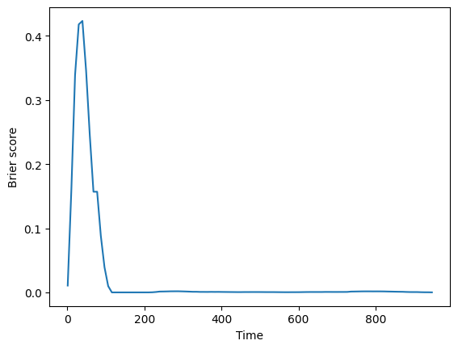

```python
time_grid = np.linspace(durations_test.min(), durations_test.max(), 100)
ev.brier_score(time_grid).plot()
plt.ylabel('Brier score')
_ = plt.xlabel('Time')
```

### Negative binomial log-likelihood

De manière similaire, nous pouvons tracer la log-vraisemblance négative binomiale IPCW.

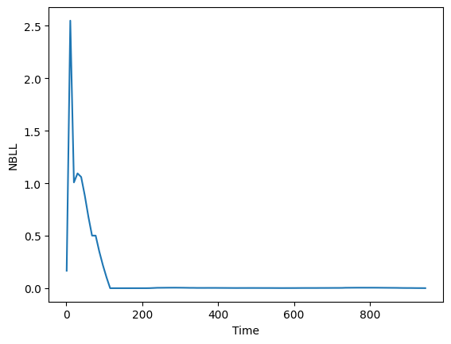

```python
ev.nbll(time_grid).plot()
plt.ylabel('NBLL')
_ = plt.xlabel('Time')
```

### Scores intégrés

Les deux scores dépendants du temps ci-dessus peuvent être intégrés sur le temps pour produire un score unique (Graf et al. 1999). En pratique, cela se fait par intégration numérique sur une grille temporelle définie.

```python
round(ev.integrated_brier_score(time_grid),4)
```

```
0.0247
```

```python
round(ev.integrated_nbll(time_grid),5)
```

```
0.09999
```